# Causal Implicature - Pilot 2 data analysis

Author

MF

```r
library(tidyverse)
library(tidyboot)
library(aida)
library(brms)
library(faintr)
library(patchwork)

##################################################

# these options help Stan run faster
options(mc.cores = parallel::detectCores())

# use the aida-theme for plotting
theme_set(theme_aida())

# global color scheme / non-optimized
project_colors = c("#E69F00", "#56B4E9", "#009E73",
                   "#F0E442", "#0072B2", "#D55E00",
                   "#CC79A7", "#000000")

# setting theme colors globally
scale_colour_discrete <- function(...) {
  scale_colour_manual(..., values = project_colors)
}
scale_fill_discrete <- function(...) {
  scale_fill_manual(..., values = project_colors)
}

##################################################

# preprocessed data from pilot 2a
d <- read_csv('01b-processed-data-pilot-2a.csv')
```

Pilot 2 uses similar methods to Pilots 1a and 1b. The main conceptual change is that an additional **reproduction task** was added at the end, in which participants were asked to reproduce the original statement by the Science Team regarding the relation between xeliherb and ralocrop. The purpose of this addition was to explore whether participants would use explicit causal language, possibly also depending on their choice (only xeliherb vs both crops).

## Study details

N=31 participants were recruited via Prolific (English Native, at least 10 previous studies, at least 90% approval rate). Participants took about 5.23 minutes for Pilot 2 on average. They were paid 0.4 British Pounds.

The experiment code, data an material are [available online](https://github.com/magpie-ea/magpie3-causal-implicature). A live version of the experiment can be tested [here](https://magpie-ea.github.io/magpie3-causal-implicature/).

The experimental material consisted of only the **association condition** from Pilot 1. As before, the critical trial involved a binary forced choice, but the information was presented in slightly layout in Pilot 2 in order to clearly demarcate what the information from the Science Team was (see Figure Figure 1).

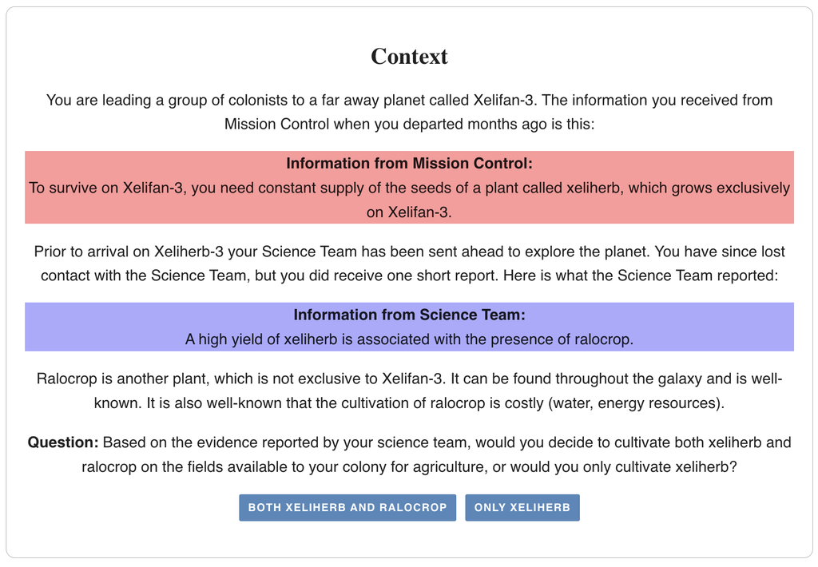

Figure 1: Screenshot from the choice trial for Pilot 2.

After the critical choice trials came a **justification trial** (as before). Following this, participants were presented with a **reproduction trial** as shown in Figure Figure 2.

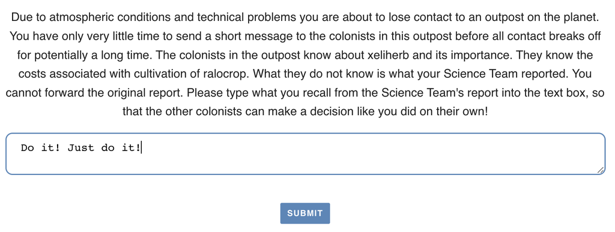

Figure 2: Screenshot from the reproduction trial for Pilot 2.

## Results

```r
proportion_both = d %>% filter(!is.na(response)) %>%
  group_by(response) %>%
  summarize(proportion = n() / (nrow(d)/3)) %>%
  .[1,2] %>% round(2)
```

The overal proportion of the BOTH option was 0.61 .

The reproductions given by participants were manually classified into three categories:

1. **causal statements:** directly implying a causal relationship (ralocrop causes high yield of xeliherb);
2. **neutral statements:** just reporting a correlation;
3. **none:** reproductions that failed to mention the relationship between the herbs.

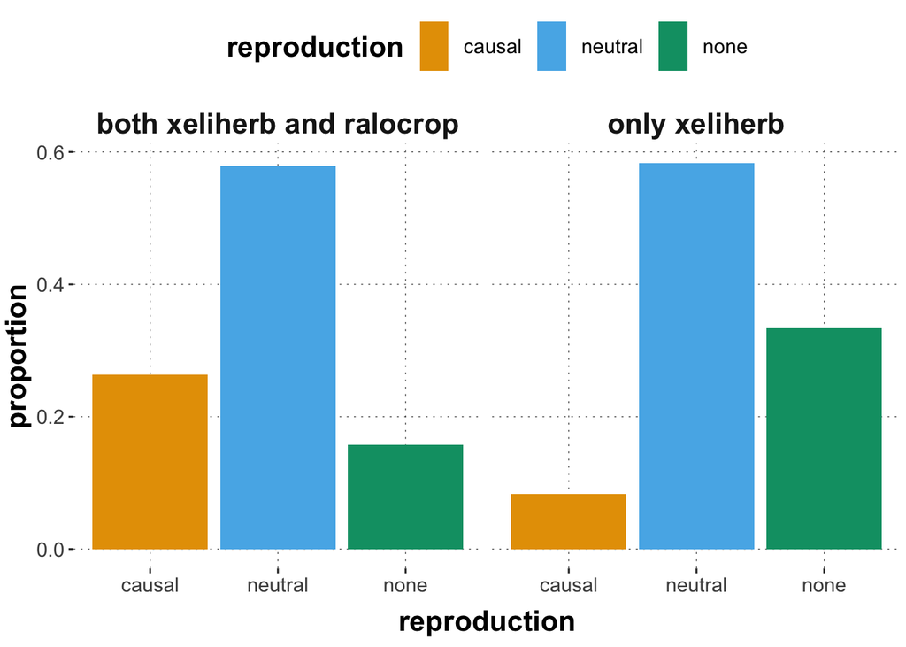

Figure 3: Proportion of reproduction types per strategy choice.

## List of all reproductions

```r
reproductions <- d %>% filter(!is.na(reproduction)) %>%
  select(submission_id, reproClass, reproduction)

knitr::kable(reproductions)
```

| submission_id | reproClass | reproduction |
| --- | --- | --- |
| 4368 | neutral | To achieve high yield of xeliherb need presence of ralocrap. |
| 4375 | neutral | To survive, colonists must have constant supply of Xeliherb. Ralocrop is associated with a high yield of xeliherb. Ralocrop can be found elsewhere in the galaxy. Ralocrop does take up water and has co… |
| 4363 | neutral | You need to harvest both for the best chance! |
| 4371 | causal | Xeliherb can be harvested at a higher yield when grown with ralocrop. |
| 4370 | neutral | Xeliherb yield is greatly increased in the presence of ralocrop. |
| 4377 | none | Ralocrop costs significantly more resources to cultivate than xeliherb. Ralocrop grows throughout the galaxy but xeliherb only grows on the planet you’re on. |
| 4365 | none | To survive on planet must have a large supply of xeliherb seeds |
| 4386 | neutral | Ralocrop was discovered growing with xeliherb |
| 4387 | neutral | High yield of xeliherb is associated with the presence of ralocrop. |
| 4392 | neutral | Ralocrop yields xeliherb. |
| 4376 | none | The science team reported that xeliherb is important to cultivate, but did not explicitly mention ralocrop. |
| 4379 | none | Ralocrop is another plant, not exclusive to the planet and is well-known throughout the galaxy. Cultivation of the crop is costly both in water and energy resources. |
| 4385 | causal | It seems that xehliherb thrives with the addition of ralocrop. |
| 4367 | neutral | If Ralocrop is present, there’s a high yield of Xeliherb. |
| 4369 | neutral | A high harvest of Xeliherb is associated with the presence of ralocrop. |
| 4378 | neutral | Ralocrop is associated with a high yield of xeliherb. |
| 4389 | neutral | The promoted growth of xeliherb is associated with the presence of ralocrop. |
| 4364 | none | there are conditions and technical problems |
| 4366 | neutral | A more abundant crop of xeliherb is associated with the proximity of ralocrop. |
| 4374 | neutral | High yields of xeliherb are associated with the presence of ralocrop |
| 4383 | causal | Science says there is a high yield of Xeliherb with ralocrop |
| 4372 | none | Science team warned that to survive on the planet must have large secured stash of xeliherb seeds. So collect seeds build a storage for the seeds |
| 4373 | causal | Ralocrop increases xeliherb yields |
| 4384 | causal | The presence of ralocrop leads to higher yield of xeliherb according to our science team. |
| 4390 | neutral | A high yield of xeliherb is associated with the presence of ralocrop. |
| 4380 | neutral | The presence of ralocrop is associated with a high yield of xeliherb. |
| 4391 | none | give priority to the cultivation of xeliherb since it is the best in terms of production costs |
| 4381 | neutral | There is a higher yield of xeliherb in the presence of ralocrop |
| 4382 | neutral | The cultivation of xeliherb on the planet is associated with a high presence of ralocrop. |
| 4388 | causal | The existence of ralocrop enhances the growth and availability of xeliherb. |
| 4393 | neutral | High yield of xeliherb is associated with the presence of ralocrop. |